# **Test a Perceptual Phenomenon by Adam McDonald**

The Stroop Effect comes from an experiment that tries to show the effect of interference on the reaction time of a task. In the test people are shown a set of names of colors printed in their respective color (e.g., the word red printed in red). The time it takes to read the set aloud is recorded. Then they are shown a set of names of colors printed in colors different than the name (e.g., the word red printed in blue). The time to read this set is recorded. In theory the congruent set will take less time to read than the incongruent set because the different colors in the incongruent set will cause interference and slow downs reaction times.

## Variables

In this experiment, the independent variable is which set is read aloud, congruent or incongruent. The dependent is the length of time that it takes the person to read the set of words aloud.

## Hypotheses

The test will be a one-sided paired t test. It will be one-sided because I am trying to determine if the time to read the incongruent set will be significantly slower than the time to read the congruent set Since the two sets were given to the same people to read, it will be a paired test. Since we only have samples and don’t know population statistics the test will be a t-test. As we will see below in the plots, the distributions of the samples are normal and we assume the population distribution would be normal as well. The size of the sample is large enough at 24, and the variance of each sample is relatively close. Based on these assumptions the use of a t-test is valid.

The null hypothesis is that the incongruent population average time to read is less than or equal to the congruent population average time to read.  
H<sub>0</sub>: $\mu$<sub>Incongruent</sub> <= $\mu$<sub>Congruent</sub>

The alternative hypothesis is that the incongruent population average time to read is greater than the congurent population average time to read.  
H<sub>A</sub>: $\mu$<sub>Incongruent</sub> > $\mu$<sub>Congruent</sub>

## Dataset

The dataset consists of 24 observations with the length of time it took to read both the congurent and incongruent sets I have also included the difference between the 2 times.

```
##    Congruent Incongruent Difference
## 1     12.079      19.278     -7.199
## 2     16.791      18.741     -1.950
## 3      9.564      21.214    -11.650
## 4      8.630      15.687     -7.057
## 5     14.669      22.803     -8.134
## 6     12.238      20.878     -8.640
## 7     14.692      24.572     -9.880
## 8      8.987      17.394     -8.407
## 9      9.401      20.762    -11.361
## 10    14.480      26.282    -11.802
## 11    22.328      24.524     -2.196
## 12    15.298      18.644     -3.346
## 13    15.073      17.510     -2.437
## 14    16.929      20.330     -3.401
## 15    18.200      35.255    -17.055
## 16    12.130      22.158    -10.028
## 17    18.495      25.139     -6.644
## 18    10.639      20.429     -9.790
## 19    11.344      17.425     -6.081
## 20    12.369      34.288    -21.919
## 21    12.944      23.894    -10.950
## 22    14.233      17.960     -3.727
## 23    19.710      22.058     -2.348
## 24    16.004      21.157     -5.153
```

## Descriptive Statistics

**Congruent Sample**  
$\bar{x}$<sub>Congruent</sub> = 14.05  
sd<sub>Congruent</sub> = 3.56

**Incongruent Sample**  
$\bar{x}$<sub>Incongruent</sub> = 22.02  
sd<sub>Incongruent</sub> = 4.80

## Histograms of Congruent and Incongruent samples

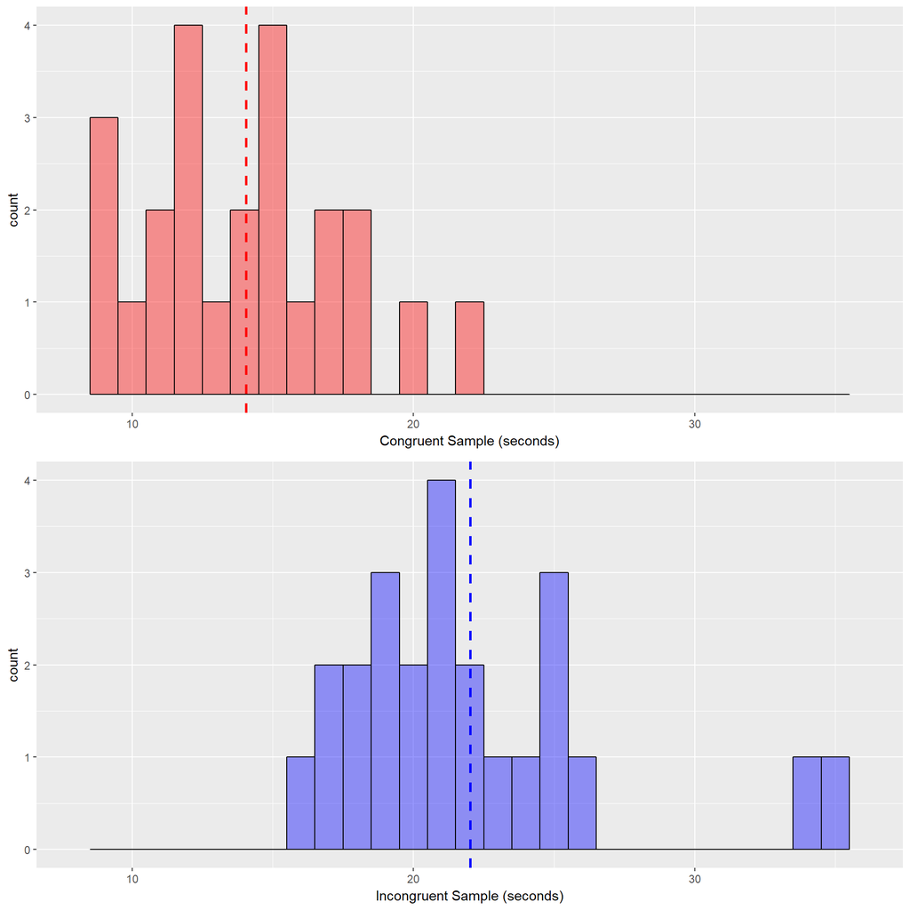

As seen in the histograms both of the samples are relatively normal, but the inconguent sample is shifted to the right of the x-axis. The t test will show if the shift right is statistically significant.

## One-Sided Paired t test

$\alpha$ = .05  
t critical = -1.71  
n = 24  
df = 23  
$\bar{x}$<sub>Congruent-Incongruent</sub> = -7.96  
s = 4.86  
se = .99  
t = -8.02  
p < .0005

Using confidence level of 95% and an $\alpha$ of .05 the t critical value is -1.71. The t statistic from the test of -8.02 is much lower than the t critical value, which means that the null hypothesis is rejected. The difference between the means of -7.96 is statistically significant. This can also be seen by comparing the $\alpha$ of .05 to the p-value. Using the t table the p-value is less than .0005, which means that it is less than the $\alpha$.

As expected changing the color used to print the color name does have an effect on reaction time. When the printed color is different than the color name it takes more time to read the word aloud.